# Correlation

# 1 Learning Objectives

- Understand the concept of two variables being correlated
- Be able to calculate the correlation coefficient $r$ from raw data
- Be able to describe a scatterplot using positive, negative, strong, perfect, weak and zero correlation
- Understand that correlation does not imply causation
- Be able to identify potential hidden variables

# 2 Correlation

What does it mean for two variables, say $x$ and $y$, to be **correlated**?

First, we should make clear that we are thinking about the $x$ and $y$ data being **ordered** in the following way:

- the first value in the $x$ data set corresponds to the first value in the $y$ data set: $(x_1,y_1)$
- the second in $x$ to the second in $y$: $(x_2, y_2)$
- continued all the way to $(x_n, y_n)$ for $n$ values in the data set

Take the example below, which contains data on father-son height pairs. In your head, try to label the below table with $x_1$ and $y_1$ and the plot with $(x_1,y_1)$.

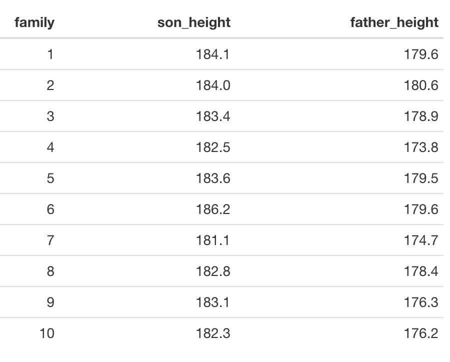

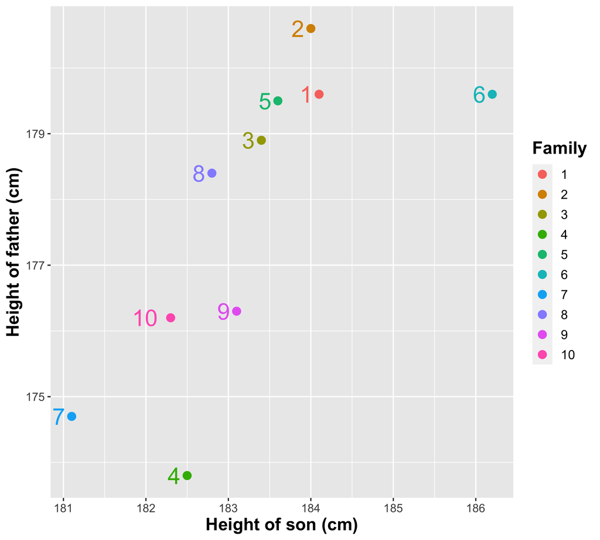

We encounter data with this structure all the time! For example, let’s look at two variables from the `mtcars` data set, namely weight `wt` and miles per gallon `mpg`

```r
library(tidyverse)
library(janitor)
```

```r
mtcars %>%
  select(wt, mpg) %>%
  glimpse()
```

```
## Rows: 32
## Columns: 2
## $ wt  <dbl> 2.620, 2.875, 2.320, 3.215, 3.440, 3.460, 3.570, 3.190, 3.150, 3.…
## $ mpg <dbl> 21.0, 21.0, 22.8, 21.4, 18.7, 18.1, 14.3, 24.4, 22.8, 19.2, 17.8,…
```

We call this data **bivariate**! This is just a fancy way of saying that it has two variables we’re interested in. Let’s plot the data with `wt` on the $x$-axis, and `mpg` on the $y$-axis

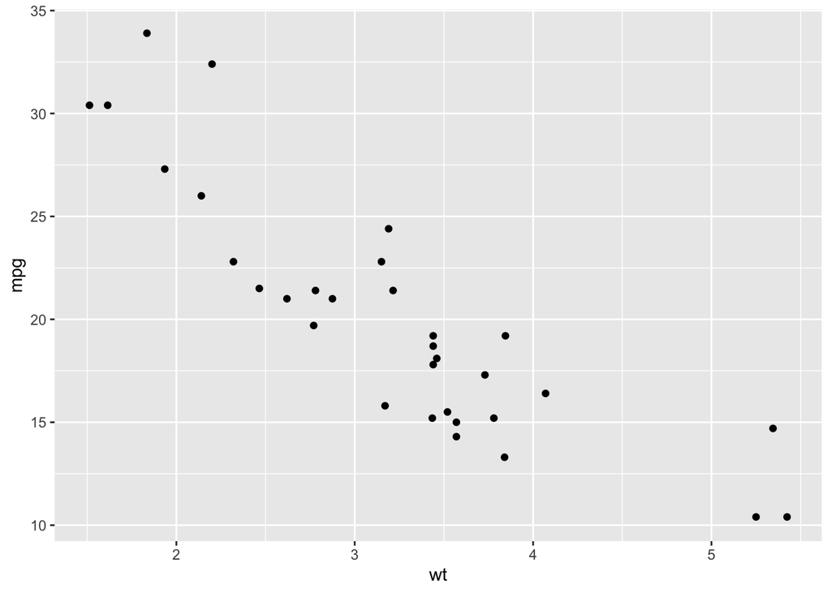

```r
mtcars %>%
  ggplot(aes(x = wt, y = mpg)) +
  geom_point()
```

Back to correlation! If $x$ and $y$ are correlated, it means that there is some apparent relationship between the ‘motion’ of $x$ and the ‘motion’ of $y$. By motion, here, we really mean the distances of $x$ and $y$ from their respective means $\bar{x}$ and $\bar{y}$.

- If $y$ is **positively correlated** with $x$ then $y-\bar{y}$ will *increase* as $x-\bar{x}$ *increases*, and *decrease* as $x-\bar{x}$ *decreases*.
- If $y$ is **negatively correlated** with $x$ then $y-\bar{y}$ will *decrease* as $x-\bar{x}$ *increases*, and *increase* as $x-\bar{x}$ *decreases*.
- Finally, if $y$ is **not correlated** with $x$ then $y-\bar{y}$ will neither *increase* nor *decrease* as $x-\bar{x}$ changes.

An easier way of thinking about whether two variables are positively or negatively correlated is to look at the general shape of the data points: if they both move in the same direction (when one increases, the other increases and when one decreases, the other decreases) they are positively correlated, and if they move in the opposite directions (when one increases, the other decreases and vice versa) they are negatively correlated. No correlation means there is no relationship in how the data points vary.

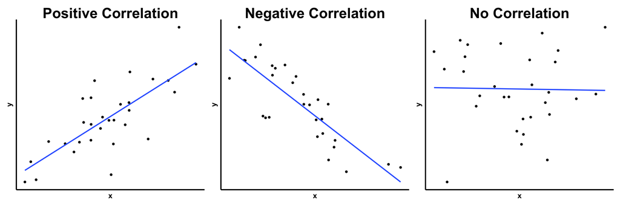

> **Task - 2 mins** Look again at the plot of `mpg` against `wt`. Do you think these variables are positively or negatively correlated, or effectively uncorrelated?

> **Solution**

> The variables are **negatively correlated**. Let’s plot the mean values of the two variables as a single point (a point known as the **centroid** of the data)

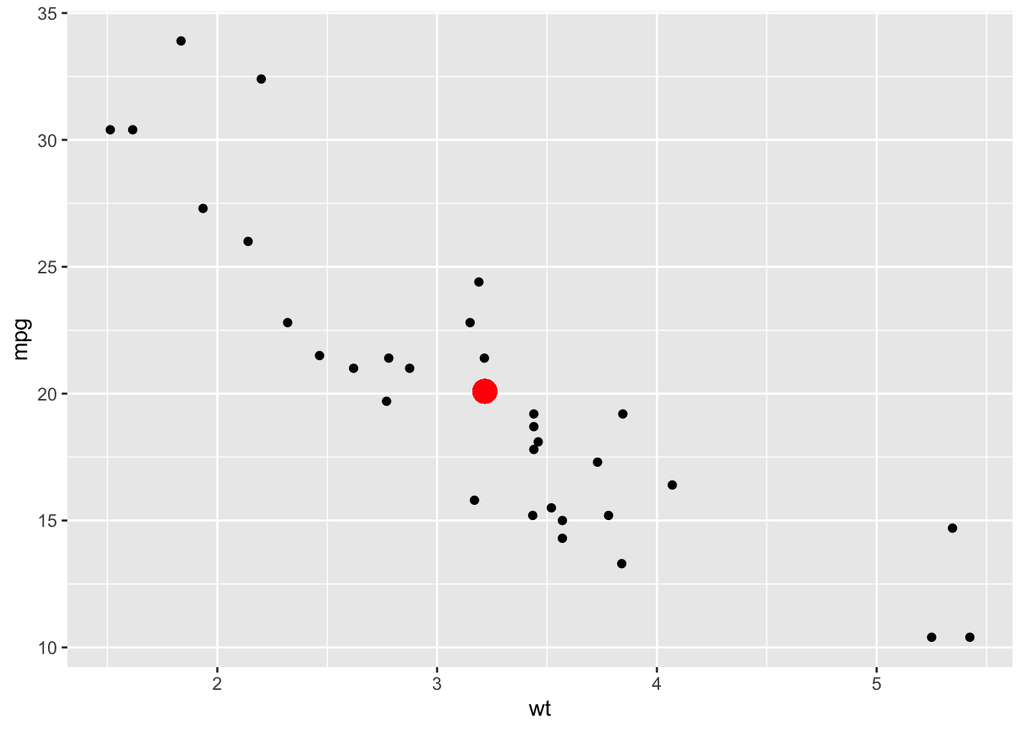

> ```r
> mtcars %>%
>   ggplot(aes(x = wt, y = mpg)) +
>   geom_point() +
>   geom_point(aes(x = mean(wt), y = mean(mpg)), col = "red", size = 5)
> ```

> Now we can see that as `wt` increases from its mean value at approx. $3.2$, `mpg` generally decreases from its mean value at approx. $20.1$, and vice-versa, so the variables are negatively correlated.

# 3 Maths details - optional

**From covariance to correlation: maths details**

This is a mathematical description of the covariance and correlation coefficient of bivariate data. **You don’t need to know any of this, we include it in case you are interested and want to know more**.

**Covariance**

Statistics provides a quantitative measure of the correlation of two variables. To get to it, however, we need to define the **covariance** of variables $x$ and $y$. For a population of size $N$ elements, the covariance $\sigma_{xy}$ is defined as

$$\sigma_{xy} = \frac{\sum_i{(x_i-\mu_x) \times (y_i-\mu_y)}}{N}$$

Let’s break this equation down and talk it through:

- First we calculate the population means of the two variables: $\mu_x$ and $\mu_y$ (these are the coordinates of the **centroid**)
- Each element of the population, labelled by index $i$, will have an $x$-value, $x_i$, and a $y$-value, $y_i$. We calculate the *signed distances* of each value from their respective means: $(x_i-\mu_x)$ and $(y_i-\mu_y)$.
- We multiply the signed distances together (i.e. take the *product*)
- We sum over all these products for each element in the population ($\sum_{i}$) and then divide by $N$. This gives us the mean of such products over the population. This is what we call the **population covariance**

**Centroid**: the point $(\mu_x, \mu_y)$ in bivariate data; or the point $(\mu_x, \mu_y, \mu_z)$ in trivariate data; and so on…

> **Task - 5 mins** Let’s stop to think what the sign of product $(x_i-\mu_x) \times (y_i-\mu_y)$ means. Mark the sign of this product on the four points on the diagram below. The population centroid $(\mu_x, \mu_y)$ is shown

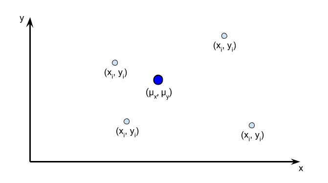

> [**Hint:** $(+\textrm{ve} \times +\textrm{ve}) = (-\textrm{ve} \times -\textrm{ve}) = +\textrm{ve}$ and $(+\textrm{ve} \times -\textrm{ve}) = (-\textrm{ve} \times +\textrm{ve}) = -\textrm{ve}$]

> **Solution**

> We can divide the plot up into four sections around the position of the centroid point. The signs of the product for any point lying in each of the four sections is shown. The product will be zero for any point lying *exactly* on any of the dashed lines.

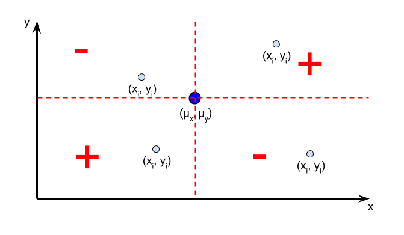

> So, as an example, the data point in the upper left section has a **negative** product because $(x_i-\mu_x)$ is negative and $(y_i-\mu_y)$ is positive. A positive times a negative number is negative.

Similarly, the **sample covariance** $s_{xy}$ for a sample of size $n$ is defined

$$s_{xy} = \frac{\sum_i{(x_i-\bar{x}) \times (y_i-\bar{y})}}{n-1}$$

The `cov()` function in R calculates the **sample covariance** for us. Let’s use it on the `mpg` and `wt` variables from `mtcars`:

```r
mtcars %>%
  summarise(cov = cov(mpg, wt))
```

| cov |
| --- |
| -5.116685 |

The value is negative, indicating that the variables `mpg` and `wt` are negatively correlated, as we thought earlier.

The units of covariance will be $\textrm{units of x} \; \times \; \textrm{units of y}$: in this case $\textrm{miles per US gallon} \; \times \; \textrm{1000 lbs}$.

**Correlation**

The **population correlation coefficient** $\rho_{xy}$ (often just written as $\rho$) is calculated from the population covariance as

$$\rho_{xy} = \frac{\sigma_{xy}}{\sigma_x \times \sigma_y} \; \; \textrm{where} \; \; -1 \leq \rho_{xy} \leq +1$$

and where $\sigma_x$ and $\sigma_y$ are the population standard deviations of variables $x$ and $y$.

Similarly, the **sample correlation coefficient** $r_{xy}$ (often just written as $r$) is calculated from the sample covariance as

$$r_{xy} = \frac{s_{xy}}{s_x \times s_y} \; \; \textrm{where} \; \; -1 \leq r_{xy} \leq +1$$

where $s_x$ and $s_y$ are the sample standard deviations of variables $x$ and $y$.

# 4 Correlation coefficient

The **Pearson correlation coefficient** denoted by $r$ measures the **linear tendency** of two variables.

- It has no units (it’s just a number)
- It takes bounded values:
  - approaching $r = 1$ when the variables are strongly positively linearly correlated
  - approaching $r = -1$ when the variables are strongly negatively linearly correlated
  - near $r = 0$ when the variables are not correlated

Values $r = +1$ or $r = -1$ indicate a **perfect linear relationship**. This just means that if we plotted the data, it would fall upon a perfect straight line. We will essentially never see this for real data sets due to random noise!

You can calculate the Pearson correlation coefficient in `R` via the `cor()` function (Pearson is the default, but other types of correlation can be calculated as well).

> **Task - 10 mins**. Let’s get to know the correlation coefficient a little better. I would say let’s get to know Pearson better, but, like Galton and Fisher, he was a social Darwinist and eugenicist, so let’s not! Unfortunately many early eminent statisticians held awful views…
> - Play around with the following function (which generates a bivariate distribution with noise). Pass in the `noise` and `gradient` values in the table below.
> - Get a sense for the $r$ values of various distributions.

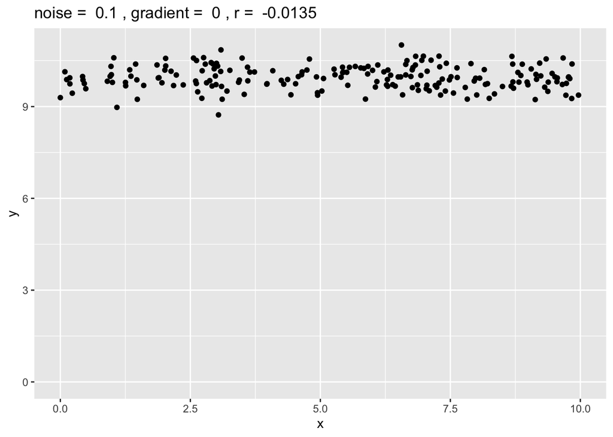

> ```r
> # SLACK THIS OUT
> noisy_bivariate <- function(noise = 1, gradient = 1){
>   x <- runif(n = 200, min = 0, max = 10)
>   y <- gradient * x + 10
>   y_scatter <- noise * 4 * rnorm(n = 200)
>   y <- y + y_scatter
>   data = tibble(x, y)
>
>   r <- round(cor(x, y), 4)
>   title <- paste(
>     "noise = ", noise,
>     ", gradient = ", gradient,
>     ", r = ", r
>   )
>
>   data %>%
>     ggplot(aes(x = x, y = y)) +
>     geom_point() +
>     xlim(0, 10) +
>     ylim(min(c(min(y), 0)), max(c(max(y), 10))) +
>     ggtitle(title)
>
> }
> noisy_bivariate(noise = 0.1, gradient = 0)
> ```

> Try the following combinations and a few more of your choosing

> | noise | gradient |
> | --- | --- |
> | 0 | 1 |
> | 0 | 0.2 |
> | 0.3 | 0.2 |
> | 0.3 | 1 |
> | 1 | 1 |
> | 1 | 0 |
> | 0 | -1 |
> | 0.3 | -1 |
> | 1 | -1 |

We’ve seen that the sign of $r$ has a simple meaning, but what about its magnitude? J. D. Evans (1996) suggests the following scale

| magnitude of $r_{xy}$ | strength of correlation |
| --- | --- |
| 0 | none |
| 0.01 - 0.19 | very weak |
| 0.20 - 0.39 | weak |
| 0.40 - 0.59 | moderate |
| 0.60 - 0.79 | strong |
| 0.80 - 0.99 | very strong |
| 1 | perfect |

Let’s calculate the correlation coefficient for the `wt` and `mpg` variables in `mtcars`:

```r
mtcars %>%
  summarise(cor(mpg, wt))
```

| cor(mpg, wt) |
| --- |
| -0.8676594 |

So we would say that these variables are very strongly negatively correlated. Let’s see if the order of variables matters:

```r
mtcars %>%
  summarise(cor(wt, mpg))
```

| cor(wt, mpg) |
| --- |
| -0.8676594 |

Nope, order doesn’t matter!

Finally, a word of warning! The correlation coefficient is a blunt instrument: we can run `cor()` on **any** bivariate dataset and **get a number out**, regardless of what the real trend (if any) is in the data.

We should always visualise data before trusting summary statistics like the correlation coefficient!

Let’s see why:

> **Task - 10 mins**

> Take a look at the four plots below:

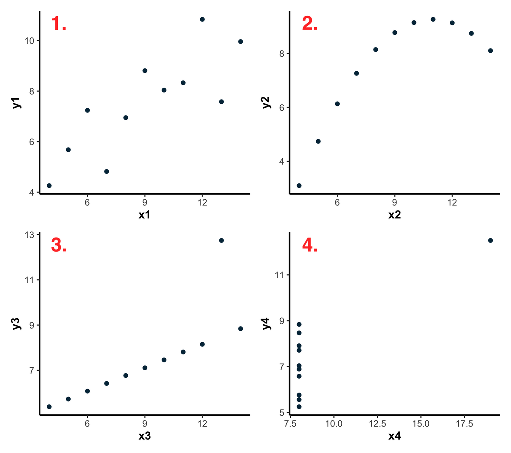

> Now calculate the four correlation coefficients between the data pairs plotted above (x1 with y1 and so on). The data can be found in the built-in `anscombe` dataset.

> ```r
> head(anscombe, 3)
> ```

> |  | x1 | x2 | x3 | x4 | y1 | y2 | y3 | y4 |
> | --- | --- | --- | --- | --- | --- | --- | --- | --- |
> | 1 | 10 | 10 | 10 | 8 | 8.04 | 9.14 | 7.46 | 6.58 |
> | 2 | 8 | 8 | 8 | 8 | 6.95 | 8.14 | 6.77 | 5.76 |
> | 3 | 13 | 13 | 13 | 8 | 7.58 | 8.74 | 12.74 | 7.71 |

> - What do you notice about the correlation coefficients?
> - Looking at each plot, think about whether the resulting coefficient accurately represents the pattern in the data.

> **Solution**

> ```r
> summarise(anscombe, cor(x1, y1))
> ```

> | cor(x1, y1) |
> | --- |
> | 0.8164205 |

> ```r
> summarise(anscombe, cor(x2, y2))
> ```

> | cor(x2, y2) |
> | --- |
> | 0.8162365 |

> ```r
> summarise(anscombe, cor(x3, y3))
> ```

> | cor(x3, y3) |
> | --- |
> | 0.8162867 |

> ```r
> summarise(anscombe, cor(x4, y4))
> ```

> | cor(x4, y4) |
> | --- |
> | 0.8165214 |

> All four datasets result in roughly the same correlation coefficient: $0.816$!

> From looking at the plots above, we can conclude that:
> - 1 looks suitable for a correlation analysis, as it looks like a linear trend with expected random spread of the data points.
> - 2 has a clearly non-linear trend, and so a classic Pearson correlation is not suitable as it assumes linearity.
> - 3 looks like a perfectly linear trend, but the presence of an outlier is highly influencing the correlation coefficient.
> - 4 shows no relationship between variables, but once again the presence of an outlier has influenced the correlation coefficient.

> These four datasets are actually referred to as *Anscombe’s Quartet* and should hopefully help you remember the importance of visualising data before analysing it, as well as the effect of outliers on descriptive statistics. I highly recommend reading more about [Anscombe’s Quartet](https://en.wikipedia.org/wiki/Anscombe%27s_quartet), because you’ll see that the correlation coefficient isn’t the only statistical property these four datasets have in common!

> So always plot data before calculating and interpreting descriptive statistics!

# 5 The most famous phrase in statistics!

What’s the most famous pithy phrase in statistics? There’s a good chance that many of you will have read or heard that

*“Correlation is not causation.”*

Just because two variables are **correlated**, it does not mean that one of them **causes** the change in the other!

Consider two variables: the number of pairs of `sunglasses_sold` and the amount of `ice_cream_sold` at a beach shop each week.

There’s a good chance that if we plot this data and calculate the correlation coefficient we’ll find that the variables are **positively correlated**.

Does this mean that an increase in the `sunglasses_sold` **causes** the amount of `ice_cream_sold` to increase? No way!! We don’t have a strong enough basis to make this conclusion.

## 5.1 The ‘third variable’ problem

The simplest realistic model might be that **both** these variables are themselves causally related with a third **‘hidden variable’**, e.g. `number_of_sunny_days` each week. An increase in `number_of_sunny_days` in a given week **causes** increases in both `sunglasses_sold` and `ice_cream_sold`!

Sometimes this is also called a **confounding variable** - a variable you **didn’t** include in your analysis that is causally related with variables that you **did** include. The presence of confounding variables makes it difficult to form conclusions about causal relationships.

> **Task - 2 mins** See if you can suggest any confounding variable(s) for the following associations:

> “1. Sleeping with shoes on is strongly correlated with waking up with a headache. Therefore, sleeping with shoes on causes headaches.”

> “2. Atmospheric CO<sub>2</sub> level and obesity levels have both increased sharply since the 1950s. Therefore, atmospheric CO<sub>2</sub> causes obesity.”

> “3. The more bacon someone eats, the higher their blood pressure. Therefore bacon causes hypertension.”

> **Solution**
> 1. Amount of alcohol consumed the day before
> 2. GDP - rich populations eat more food and produce more CO<sub>2</sub>
> 3. Preference for salty food - more likely to eat bacon, more likely to have hypertension

## 5.2 The ‘directionality’ problem

Even if the two variables **are** causally related, there is nothing in the statistics to indicate the **directionality** of causation.

Imagine a study on the positive effects of exercise with two variables measured:

- `amount_of_exercise` in a given week.
- `happiness` in a given week.

If we discover a positive correlation between these variables, we would be tempted to suggest that it is an increase in the amount of exercise that **causes** an increase in happiness, however it is also possible that the causal direction is the opposite i.e. happier people exercise more.

A well-known example of the directionality problem is whether exposure to violence in video games or on TV causes aggressive behaviour or whether someone with aggressive behaviour is just more likely to consume violent media.

As both of these cases apply to something as complex as human behaviour, there is also a high chance that there are confounding variables that need to be accounted for.

## 5.3 How do we prove causation?

This sounds like a minefield! How do we **prove** causation between variables if strong correlation isn’t enough?

Ideally with a **randomised controlled experiment**.

In this experiment, we:

1. **Randomly** split our experimental sample into two groups: ‘control’ and ‘treatment’, and try to make sure sample elements with potentially confounding factors are spread as evenly as possible over both groups and/or restricted to a small range
   - e.g. if age is a potential confounder, use stratified sampling by age to form the control and treatment groups, or limit the experiment to say 20-30 year old people
2. Next, make some active intervention (i.e. **change** the variable we are testing the effect of) with the ‘treatment’ group, and do not intervene at all with the ‘control’ group.
3. Gather and analyse outcome data from both groups.

This study gives us the basis to say whether or not our ‘intervention’ variable **causes** any change we find in the ‘outcome’ variable.

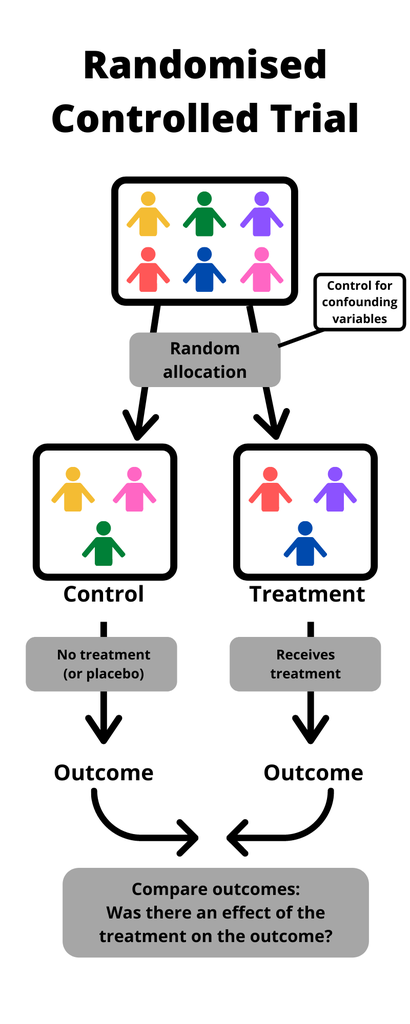

**Hill’s Criteria of Causality** are also a useful guide. The following summary of them comes from the excellent [Stats With Cats blog](https://statswithcats.wordpress.com/)!

- **Strength:** A relationship is more likely to be causal if the correlation coefficient is large and statistically significant.
- **Consistency:** A relationship is more likely to be causal if it can be replicated.
- **Specificity:** A relationship is more likely to be causal if there is no other likely explanation.
- **Temporality:** A relationship is more likely to be causal if the effect always occurs after the cause.
- **Gradient:** A relationship is more likely to be causal if a greater exposure to the suspected cause leads to a greater effect.
- **Plausibility:** A relationship is more likely to be causal if there is a plausible mechanism between the cause and the effect.
- **Coherence:** A relationship is more likely to be causal if it is compatible with related facts and theories.
- **Experiment:** A relationship is more likely to be causal if it can be verified experimentally.
- **Analogy:** A relationship is more likely to be causal if there are proven relationships between similar causes and effects.

# 6 Optional task - extra practice

> **Task - 15 mins** Let’s calculate correlation coefficients for various variables in the `state.x77` dataset!
> - Examine the contents of this dataset (try accessing documentation via `?state.x77` or running `summary()` on it).
> - Choose a few combinations of variables to plot as $y$ versus $x$ and calculate the correlation coefficients for the same combinations. Do you find any strong correlations?
> - Have a think about what kind of evidence you would need to be able to claim that any of the correlations you find are due to a causal relationship between the variables.

> [**Hint** the dataset is a `matrix` so convert it to a `tibble` first via `tibble_states <- clean_names(as_tibble(state.x77))` to make manipulations easier].

> **Solution**

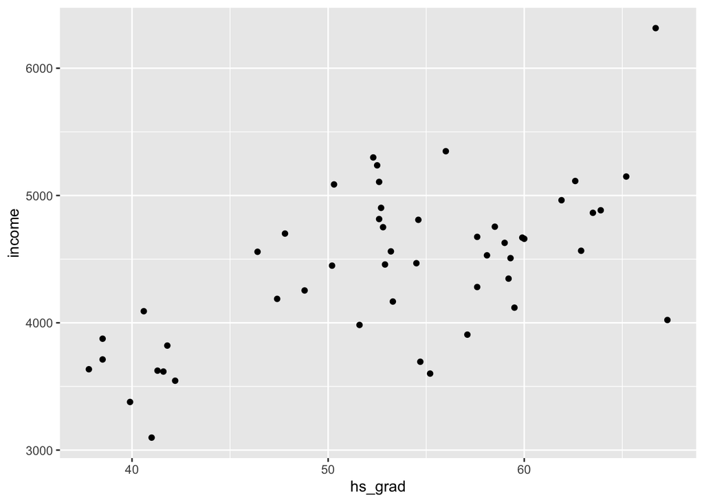

> ```r
> # Let's look at some interesting plots!
> tibble_states <- clean_names(as_tibble(state.x77))
>
> tibble_states %>%
>   ggplot(aes(x = hs_grad, y = income)) +
>   geom_point()
> ```

> ```r
> tibble_states %>%
>   summarise(r = cor(hs_grad, income))
> ```

> | r |
> | --- |
> | 0.6199323 |

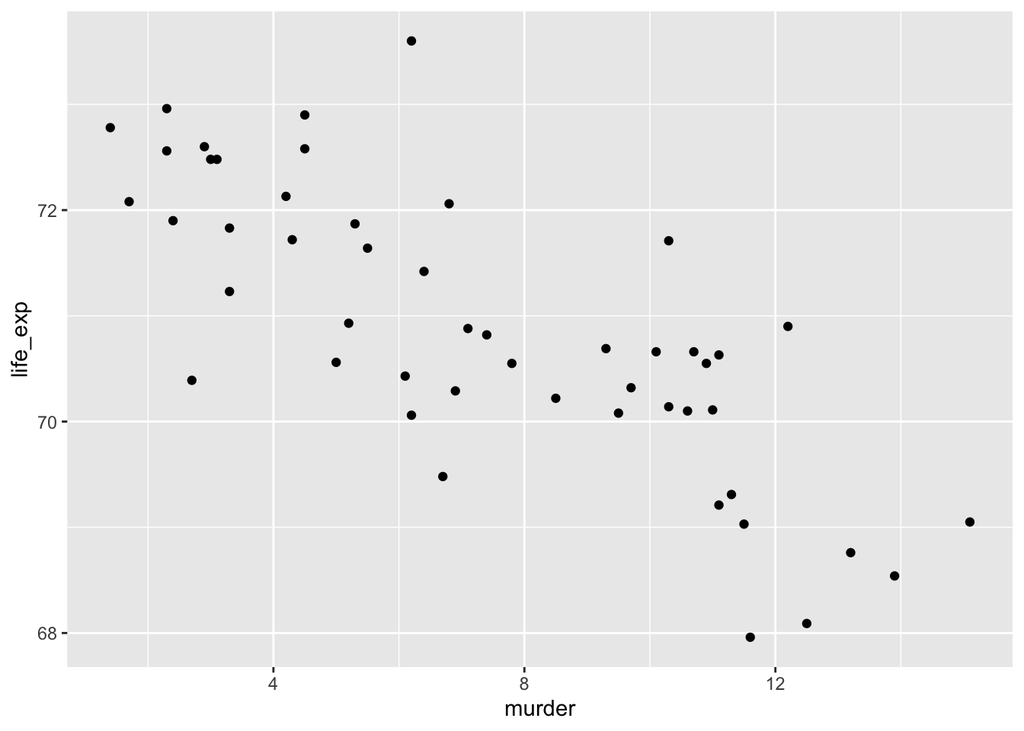

> ```r
> tibble_states %>%
>   ggplot(aes(x = murder, y = life_exp)) +
>   geom_point()
> ```

> ```r
> tibble_states %>%
>   summarise(r = cor(murder, life_exp))
> ```

> | r |
> | --- |
> | -0.7808458 |

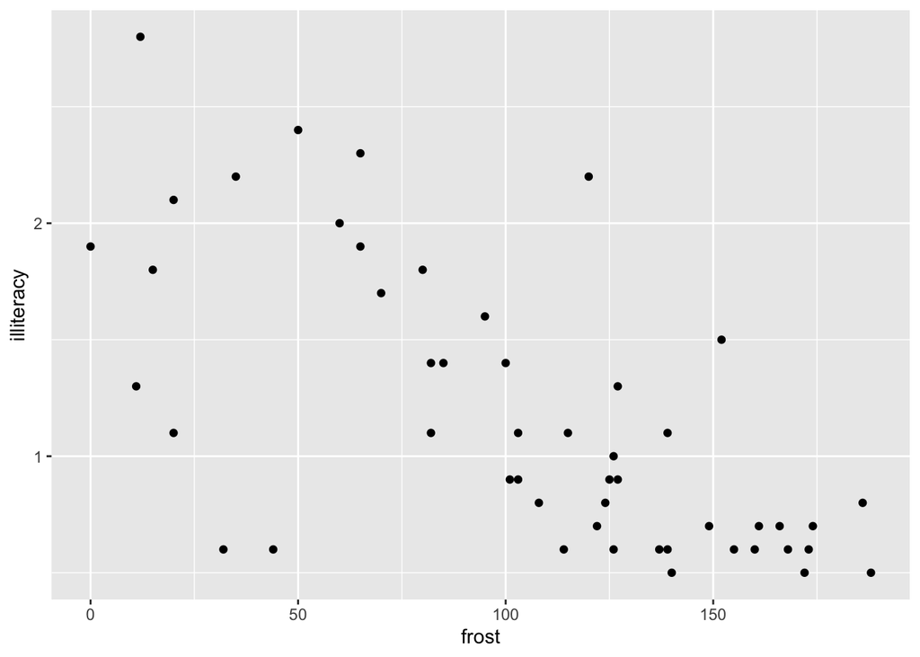

> ```r
> tibble_states %>%
>   ggplot(aes(x = frost, y = illiteracy)) +
>   geom_point()
> ```

> ```r
> tibble_states %>%
>   summarise(r = cor(frost, illiteracy))
> ```

> | r |
> | --- |
> | -0.671947 |

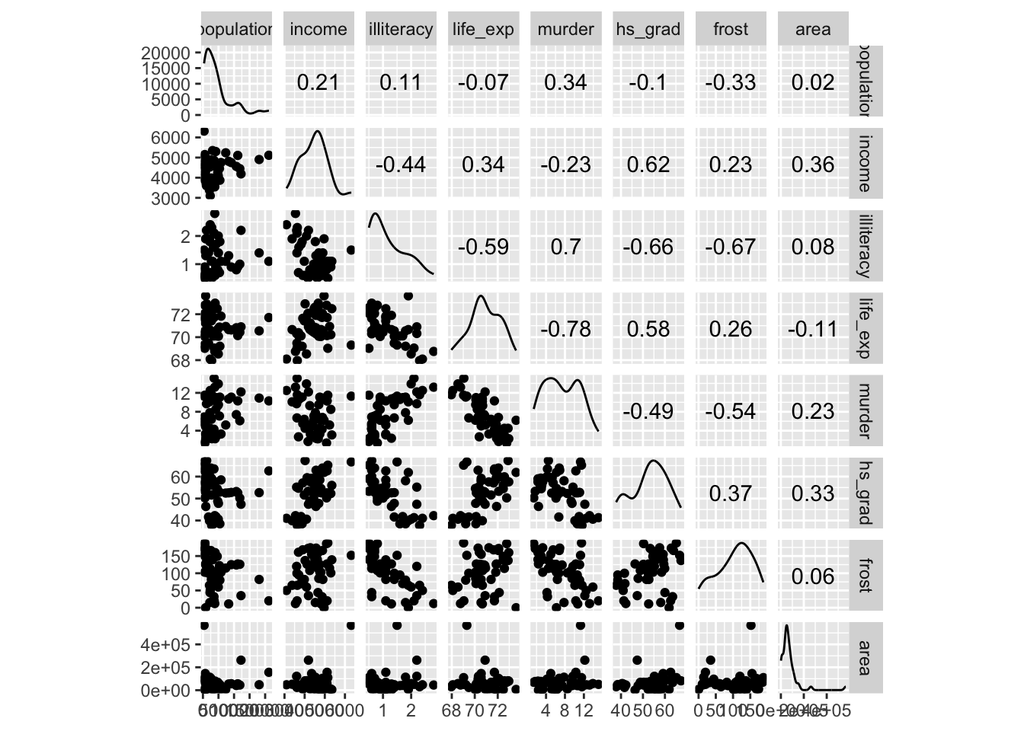

> ```r
> # Useful hint, you can pass the whole tibble into ggpairs() or ggcorr() from the GGally package
> # to get a cross plot of correlation coefficients.
> # Be careful though, this starts to smell of 'fishing' data for interesting effects.
> library(GGally)
> tibble_states %>%
>   ggscatmat()
> ```

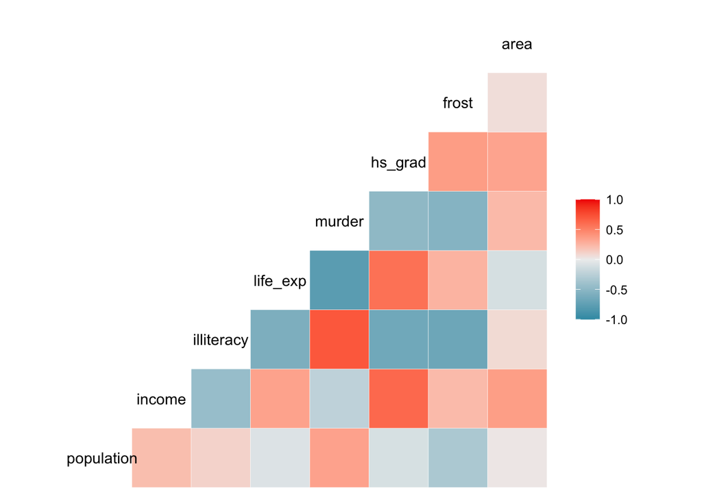

> ```r
> # or
> tibble_states %>%
>   ggcorr()
> ```

# 7 Additional Resources

- [Cool interactive visualization of correlations](https://rpsychologist.com/correlation/)
- [A good overview of different correlation methods](https://easystats.github.io/correlation/articles/types.html)

# 8 Recap

What does it mean for two variables $x$ and $y$ to be positively correlated or negatively correlated?

**Answer**

Positive correlation: as $x$ increases, $y$ tends to increase, and vice-versa  
Negative correlation: as $x$ increases, $y$ tends to decrease, and vice-versa

What values of Pearson correlation coefficient do we expect for nearly perfect linear relationships? For variables which are uncorrelated?

**Answer**

Nearly perfect linear relationships: $r = +1$ or $r = -1$ Uncorrelated variables: $r = 0$

What is a ‘hidden’ variable (AKA a ‘confounding’ variable)?

**Answer**

A variable not included in your analysis that is causally related with variables that are included in your analysis.

How might we prove a causal relationship between two variables?

**Answer**

By performing a controlled statistical experiment, preferably with randomised assignment of units to ‘control’ and ‘treatment’ groups to minimise the effect of potential confounders.